# Describing a Categorical Variable

Companion `R` Code for Stats 101 Video Lesson

Created by Jill E. Thomley, Appalachian State University

Last updated on Monday, March 14, 2022 @ 07:39 PM

▶ [GO TO VIDEO](https://youtu.be/vrWYw8d2830)

## Packages Used

```r
library(tidyverse)
```

## Smartphone User Example

### Read in the Dataset

The data is in a CSV file stored on the web, so we will read it into RStudio using `read_csv()` from the tidyverse package (which has been loaded above). It is always good to inspect the structure of a dataset, especially if you have not used it before.

```r
URL <- "https://raw.githubusercontent.com/STAT-JET-ASU/Datasets/master/Stats101/stats101smartphones.csv"
smartphones <- read_csv(URL)
glimpse(smartphones)
```

```
Rows: 100
Columns: 2
$ brand <chr> "Apple", "LG", "Apple", "Samsung", "Apple", "Other", "Apple", "L…
$ age   <dbl> 58, 22, 28, 68, 39, 44, 26, 27, 25, 66, 23, 54, 48, 31, 50, 41, …
```

```r
head(smartphones)
```

```
# A tibble: 6 × 2
  brand     age
  <chr>   <dbl>
1 Apple      58
2 LG         22
3 Apple      28
4 Samsung    68
5 Apple      39
6 Other      44
```

### Make `brand` a Factor

We can convert `brand` into a factor variable so the categories are ordered the way we want.

```r
# extract and alphabetize the category names

sortedcats <- sort(unique(smartphones$brand))
sortedcats
```

```
[1] "Apple"    "HTC"      "LG"       "Motorola" "Other"    "Samsung"
```

```r
# move the 'Other' category to the end
# you need to switch positions 5 and 6
# indices [i] are the vector locations

categories <- c(sortedcats[1:4], sortedcats[6], sortedcats[5])
categories
```

```
[1] "Apple"    "HTC"      "LG"       "Motorola" "Samsung"  "Other"
```

```r
# you could also manually type the order, since this is a short vector
# however, big picture, manual inputs in code are not very reproducible
# categories <- c("Apple", "HTC", "LG", "Motorola", "Samsung", "Other")

# mutate into a factor variable

smartphones <- smartphones %>%
  mutate(brand = factor(brand, levels = categories))

# check structure, now brand is a <fct> versus <chr>

glimpse(smartphones)
```

```
Rows: 100
Columns: 2
$ brand <fct> Apple, LG, Apple, Samsung, Apple, Other, Apple, LG, Apple, Apple…
$ age   <dbl> 58, 22, 28, 68, 39, 44, 26, 27, 25, 66, 23, 54, 48, 31, 50, 41, …
```

### Frequency Distribution

Most methods for creating frequency distributions in `R` do not automatically add the totals, since we may want to use the “table” in further operations. We can use other methods to calculate totals. Because we are using the **dplyr** package function `count()`, the output will be a tibble. This is useful because we can easily perform other operations on it.

```r
smartphones %>%
  count(brand)
```

```
# A tibble: 6 × 2
  brand        n
  <fct>    <int>
1 Apple       45
2 HTC          2
3 LG          10
4 Motorola     4
5 Samsung     28
6 Other       11
```

```r
smartphones %>%
  count(brand) %>%
  summarize(total = sum(n))
```

```
# A tibble: 1 × 1
  total
  <int>
1   100
```

A better way to do this would be to save the frequency distribution as an object to avoid redundant coding.

```r
phonedist1 <- smartphones %>%
  count(brand)
phonedist1
```

```
# A tibble: 6 × 2
  brand        n
  <fct>    <int>
1 Apple       45
2 HTC          2
3 LG          10
4 Motorola     4
5 Samsung     28
6 Other       11
```

```r
phonedist1 %>%
  summarize(total = sum(n))
```

```
# A tibble: 1 × 1
  total
  <int>
1   100
```

### Frequency Bar Plot

#### Bare-Bones Bar Plot

If you are exploring your data, you can make a quick and simple plot like the one below.

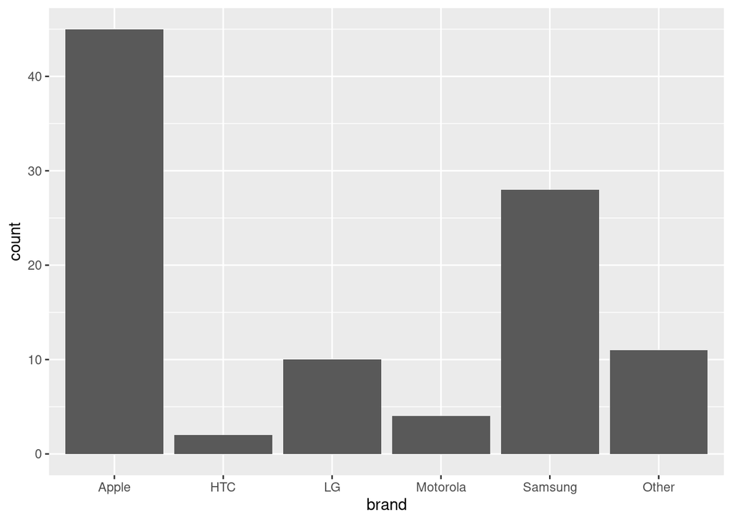

```r
ggplot(smartphones, aes(x = brand)) +
  geom_bar()
```

#### Formatted Bar Plot

If you are presenting your data, you should at least add a title and better axis labels. This plot is formatted to resemble the one in the video by changing the bar colors, bar widths, y-axis scaling/numbering, and removing some grid lines. Colors can be specified using names, hex codes, or RGB codes. The function `colors()` will show you what color names `R` recognizes.

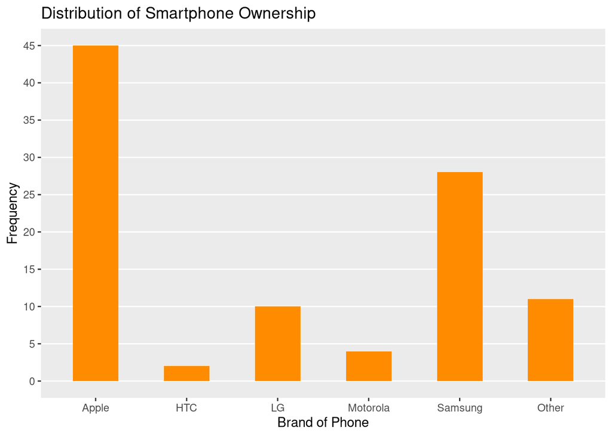

```r
ggplot(smartphones, aes(x = brand)) +
  geom_bar(fill = "darkorange", width = 0.5) +
  scale_y_continuous(breaks = seq(0, 50, by = 5)) +
  labs(
    title = "Distribution of Smartphone Ownership",
    x = "Brand of Phone",
    y = "Frequency"
  ) +
  theme(
    panel.grid.major.x = element_blank(),
    panel.grid.minor.y = element_blank()
  )
```

#### Using the “Table”

You can also make a bar plot from your saved frequency distribution object using `geom_col()`. This plot can be formatted in the same way as the one above, which is one major advantage of using ggplot2.

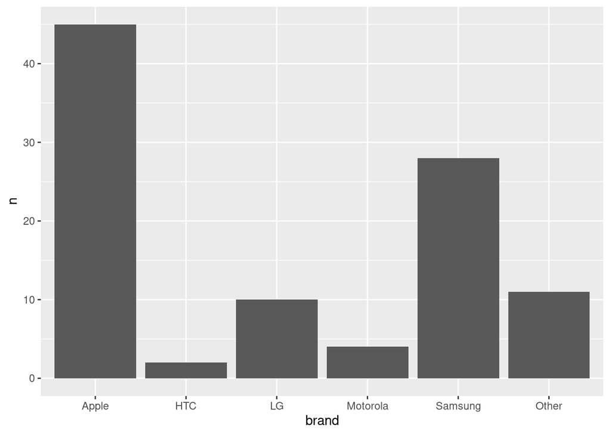

```r
ggplot(phonedist1, aes(x = brand, y = n)) +
  geom_col()
```

### Relative Fequencies

```r
smartphones %>%
  count(brand) %>%
  mutate(rel_freq = prop.table(n))
```

```
# A tibble: 6 × 3
  brand        n rel_freq
  <fct>    <int>    <dbl>
1 Apple       45     0.45
2 HTC          2     0.02
3 LG          10     0.1
4 Motorola     4     0.04
5 Samsung     28     0.28
6 Other       11     0.11
```

We also could have used the distribution we saved above to avoid re-typing the same code. You should think about these kinds of things when planning your workflow. We can also rename `n` to be `frequency`.

```r
phonedist2 <- phonedist1 %>%
  mutate(rel_freq = prop.table(n)) %>%
  rename(frequency = n)
phonedist2
```

```
# A tibble: 6 × 3
  brand    frequency rel_freq
  <fct>        <int>    <dbl>
1 Apple           45     0.45
2 HTC              2     0.02
3 LG              10     0.1
4 Motorola         4     0.04
5 Samsung         28     0.28
6 Other           11     0.11
```

```r
phonedist2 %>%
  summarize(
    total_frequency = sum(frequency),
    total_rel_freq = sum(rel_freq)
  )
```

```
# A tibble: 1 × 2
  total_frequency total_rel_freq
            <int>          <dbl>
1             100              1
```

### Relative Frequency Bar Plot

#### Bare-Bones Bar Plot

We have to instruct ggplot2 to compute relative frequencies from the data.

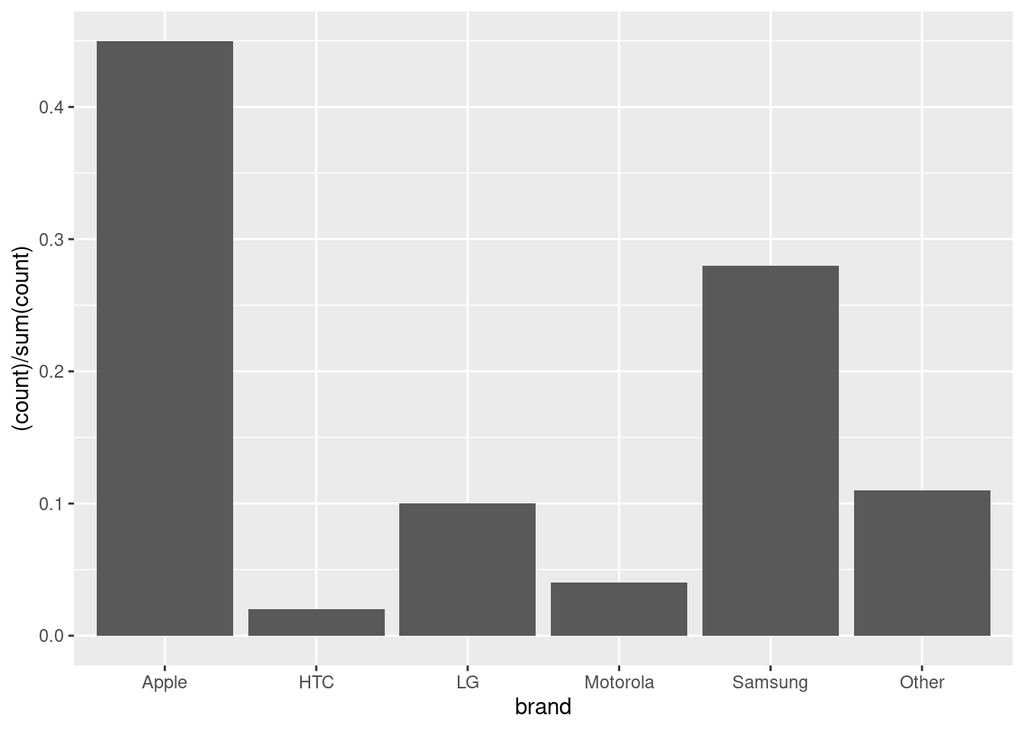

```r
ggplot(smartphones, aes(x = brand)) +
  geom_bar(aes(y = (..count..) / sum(..count..)))
```

#### Formatted Bar Plot

If you are presenting your data, you should at least add a title and better axis labels. This plot is formatted to resemble the one in the video by changing the colors, bar widths, y-axis numbering, and the grid lines.

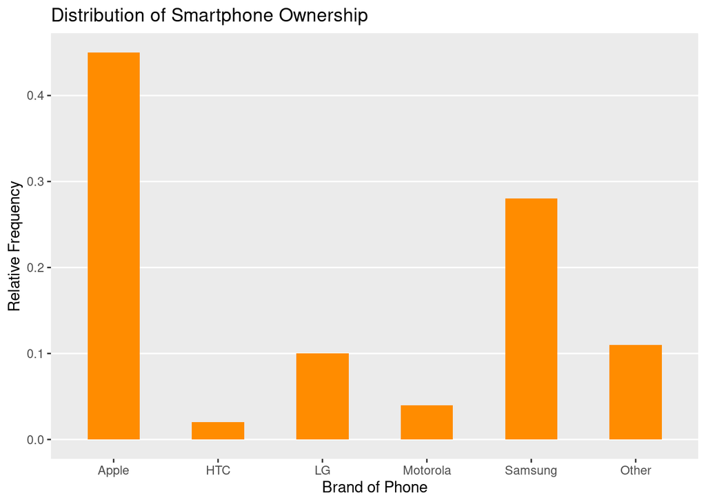

```r
ggplot(smartphones, aes(x = brand)) +
  geom_bar(aes(y = (..count..) / sum(..count..)),
    fill = "darkorange",
    width = 0.5
  ) +
  scale_y_continuous(breaks = seq(0, 0.5, by = 0.1)) +
  labs(
    title = "Distribution of Smartphone Ownership",
    x = "Brand of Phone",
    y = "Relative Frequency"
  ) +
  theme(
    panel.grid.major.x = element_blank(),
    panel.grid.minor.y = element_blank()
  )
```

#### Using the “Table”

Again, you can also make a bar plot from your saved frequency distribution object using `geom_col()`.

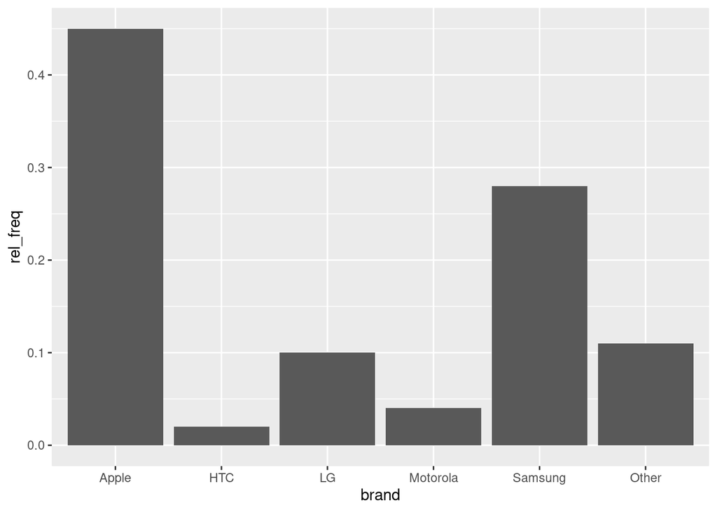

```r
ggplot(phonedist2, aes(x = brand, y = rel_freq)) +
  geom_col()
```

### References

Tidyverse: [Bar Charts](https://ggplot2.tidyverse.org/reference/geom_bar.html)